# Исследование объявлений о продаже квартир

**Цель исследования:**  
Основная цель проекта заключается в проведении комплексного анализа данных о рынке недвижимости Санкт-Петербурга и разработке методологии определения рыночной стоимости квартир на основе множества параметров.

По каждой квартире на продажу доступны два вида данных. Первые вписаны пользователем, вторые — получены автоматически на основе картографических данных. Например, расстояние до центра, аэропорта и других объектов — эти данные автоматически получены из геосервисов. Количество парков и водоёмов также заполняется без участия пользователя.

**Описание данных:**

- `airports_nearest` — расстояние до ближайшего аэропорта в метрах (м)
- `balcony` — число балконов
- `ceiling_height` — высота потолков (м)
- `cityCenters_nearest` — расстояние до центра города (м)
- `days_exposition` — сколько дней было размещено объявление (от публикации до снятия)
- `first_day_exposition` — дата публикации
- `floor` — этаж
- `floors_total` — всего этажей в доме
- `is_apartment` — апартаменты (булев тип)
- `kitchen_area` — площадь кухни в квадратных метрах (м²)
- `last_price` — цена на момент снятия с публикации
- `living_area` — жилая площадь в квадратных метрах (м²)
- `locality_name` — название населённого пункта
- `open_plan` — свободная планировка (булев тип)
- `parks_around3000` — число парков в радиусе 3 км
- `parks_nearest` — расстояние до ближайшего парка (м)
- `ponds_around3000` — число водоёмов в радиусе 3 км
- `ponds_nearest` — расстояние до ближайшего водоёма (м)
- `rooms` — число комнат
- `studio` — квартира-студия (булев тип)
- `total_area` — общая площадь квартиры в квадратных метрах (м²)
- `total_images` — число фотографий квартиры в объявлении

## Загрузка данных

```python
# Импорт необходимых библиотек
import pandas as pd
import matplotlib.pyplot as plt
try:
    from google.colab import drive
    drive.mount('/content/drive')
except ImportError:
    print('Код выполняется вне Google Colab.')
```

```
Код выполняется вне Google Colab.
```

```python
# Настройка отоброжения и подключение Google Colab
pd.set_option('display.max_columns', None)
pd.set_option('display.max_rows', None)
```

```python
try:
    data = pd.read_csv('/datasets/real_estate_data.csv', sep='\t')  # Для практикума
except FileNotFoundError:
    try:
        data = pd.read_csv('../Модуль 1 спринт 1/real_estate_data.csv', sep='\t')  # Если файл локальный
    except FileNotFoundError:
        try:
            data = pd.read_csv('/content/drive/MyDrive/Colab Notebooks/Модуль 1/Модуль 1 спринт 1/real_estate_data.csv', sep='\t')  # Для Google Colab
        except FileNotFoundError:
            print('Файл не найден ни в одном из указанных мест.')
```

Выполним первичный анализ данных.

```python
data.info()
```

```
<class 'pandas.core.frame.DataFrame'>
RangeIndex: 23699 entries, 0 to 23698
Data columns (total 22 columns):
 #   Column                Non-Null Count  Dtype
---  ------                --------------  -----
 0   total_images          23699 non-null  int64
 1   last_price            23699 non-null  float64
 2   total_area            23699 non-null  float64
 3   first_day_exposition  23699 non-null  object
 4   rooms                 23699 non-null  int64
 5   ceiling_height        14504 non-null  float64
 6   floors_total          23613 non-null  float64
 7   living_area           21796 non-null  float64
 8   floor                 23699 non-null  int64
 9   is_apartment          2775 non-null   object
 10  studio                23699 non-null  bool
 11  open_plan             23699 non-null  bool
 12  kitchen_area          21421 non-null  float64
 13  balcony               12180 non-null  float64
 14  locality_name         23650 non-null  object
 15  airports_nearest      18157 non-null  float64
 16  cityCenters_nearest   18180 non-null  float64
 17  parks_around3000      18181 non-null  float64
 18  parks_nearest         8079 non-null   float64
 19  ponds_around3000      18181 non-null  float64
 20  ponds_nearest         9110 non-null   float64
 21  days_exposition       20518 non-null  float64
dtypes: bool(2), float64(14), int64(3), object(3)
memory usage: 3.7+ MB
```

```python
data.head(10)
```

|  | total_images | last_price | total_area | first_day_exposition | rooms | ceiling_height | floors_total | living_area | floor | is_apartment | studio | open_plan | kitchen_area | balcony | locality_name | airports_nearest | cityCenters_nearest | parks_around3000 | parks_nearest | ponds_around3000 | ponds_nearest | days_exposition |
| --- | --- | --- | --- | --- | --- | --- | --- | --- | --- | --- | --- | --- | --- | --- | --- | --- | --- | --- | --- | --- | --- | --- |
| 0 | 20 | 13000000.0 | 108.00 | 2019-03-07T00:00:00 | 3 | 2.70 | 16.0 | 51.00 | 8 | NaN | False | False | 25.00 | NaN | Санкт-Петербург | 18863.0 | 16028.0 | 1.0 | 482.0 | 2.0 | 755.0 | NaN |
| 1 | 7 | 3350000.0 | 40.40 | 2018-12-04T00:00:00 | 1 | NaN | 11.0 | 18.60 | 1 | NaN | False | False | 11.00 | 2.0 | посёлок Шушары | 12817.0 | 18603.0 | 0.0 | NaN | 0.0 | NaN | 81.0 |
| 2 | 10 | 5196000.0 | 56.00 | 2015-08-20T00:00:00 | 2 | NaN | 5.0 | 34.30 | 4 | NaN | False | False | 8.30 | 0.0 | Санкт-Петербург | 21741.0 | 13933.0 | 1.0 | 90.0 | 2.0 | 574.0 | 558.0 |
| 3 | 0 | 64900000.0 | 159.00 | 2015-07-24T00:00:00 | 3 | NaN | 14.0 | NaN | 9 | NaN | False | False | NaN | 0.0 | Санкт-Петербург | 28098.0 | 6800.0 | 2.0 | 84.0 | 3.0 | 234.0 | 424.0 |
| 4 | 2 | 10000000.0 | 100.00 | 2018-06-19T00:00:00 | 2 | 3.03 | 14.0 | 32.00 | 13 | NaN | False | False | 41.00 | NaN | Санкт-Петербург | 31856.0 | 8098.0 | 2.0 | 112.0 | 1.0 | 48.0 | 121.0 |
| 5 | 10 | 2890000.0 | 30.40 | 2018-09-10T00:00:00 | 1 | NaN | 12.0 | 14.40 | 5 | NaN | False | False | 9.10 | NaN | городской посёлок Янино-1 | NaN | NaN | NaN | NaN | NaN | NaN | 55.0 |
| 6 | 6 | 3700000.0 | 37.30 | 2017-11-02T00:00:00 | 1 | NaN | 26.0 | 10.60 | 6 | NaN | False | False | 14.40 | 1.0 | посёлок Парголово | 52996.0 | 19143.0 | 0.0 | NaN | 0.0 | NaN | 155.0 |
| 7 | 5 | 7915000.0 | 71.60 | 2019-04-18T00:00:00 | 2 | NaN | 24.0 | NaN | 22 | NaN | False | False | 18.90 | 2.0 | Санкт-Петербург | 23982.0 | 11634.0 | 0.0 | NaN | 0.0 | NaN | NaN |
| 8 | 20 | 2900000.0 | 33.16 | 2018-05-23T00:00:00 | 1 | NaN | 27.0 | 15.43 | 26 | NaN | False | False | 8.81 | NaN | посёлок Мурино | NaN | NaN | NaN | NaN | NaN | NaN | 189.0 |
| 9 | 18 | 5400000.0 | 61.00 | 2017-02-26T00:00:00 | 3 | 2.50 | 9.0 | 43.60 | 7 | NaN | False | False | 6.50 | 2.0 | Санкт-Петербург | 50898.0 | 15008.0 | 0.0 | NaN | 0.0 | NaN | 289.0 |

```python
data.tail()
```

|  | total_images | last_price | total_area | first_day_exposition | rooms | ceiling_height | floors_total | living_area | floor | is_apartment | studio | open_plan | kitchen_area | balcony | locality_name | airports_nearest | cityCenters_nearest | parks_around3000 | parks_nearest | ponds_around3000 | ponds_nearest | days_exposition |
| --- | --- | --- | --- | --- | --- | --- | --- | --- | --- | --- | --- | --- | --- | --- | --- | --- | --- | --- | --- | --- | --- | --- |
| 23694 | 9 | 9700000.0 | 133.81 | 2017-03-21T00:00:00 | 3 | 3.7 | 5.0 | 73.3 | 3 | NaN | False | False | 13.83 | NaN | Санкт-Петербург | 24665.0 | 4232.0 | 1.0 | 796.0 | 3.0 | 381.0 | NaN |
| 23695 | 14 | 3100000.0 | 59.00 | 2018-01-15T00:00:00 | 3 | NaN | 5.0 | 38.0 | 4 | NaN | False | False | 8.50 | NaN | Тосно | NaN | NaN | NaN | NaN | NaN | NaN | 45.0 |
| 23696 | 18 | 2500000.0 | 56.70 | 2018-02-11T00:00:00 | 2 | NaN | 3.0 | 29.7 | 1 | NaN | False | False | NaN | NaN | село Рождествено | NaN | NaN | NaN | NaN | NaN | NaN | NaN |
| 23697 | 13 | 11475000.0 | 76.75 | 2017-03-28T00:00:00 | 2 | 3.0 | 17.0 | NaN | 12 | NaN | False | False | 23.30 | 2.0 | Санкт-Петербург | 39140.0 | 10364.0 | 2.0 | 173.0 | 3.0 | 196.0 | 602.0 |
| 23698 | 4 | 1350000.0 | 32.30 | 2017-07-21T00:00:00 | 1 | 2.5 | 5.0 | 12.3 | 1 | NaN | False | False | 9.00 | NaN | поселок Новый Учхоз | NaN | NaN | NaN | NaN | NaN | NaN | NaN |

Гистограммы по числовым столбцам датафрейма

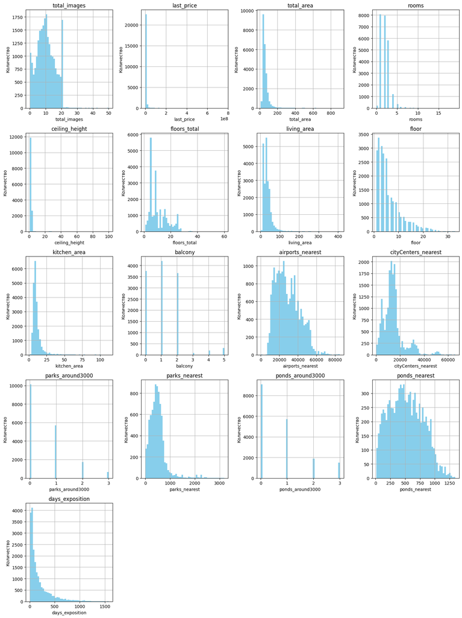

```python
fig, axes = plt.subplots(nrows=5, ncols=4, figsize=(15, 20))
axes = axes.flatten()

for i, j in enumerate(data.select_dtypes(include='number')):
    axes[i].hist(data[j], bins=50, color='skyblue')
    axes[i].grid(True)
    axes[i].set_title(f'{j}')
    axes[i].set_xlabel(j)
    axes[i].set_ylabel('Количество')

# Убираем пустые подграфики, если они есть
for j in range(i + 1, len(axes)):
    fig.delaxes(axes[j])

plt.tight_layout()  # Корректируем расположение графиков
plt.show()
```

Промежуточный вывод:

- Графики (слева на право) 2, 3, 4, 5, 7, 9, 14, 17 имеют не хакетерный для гистограмм, тип распределния
- Столбец `its_apertment` должене иметь булевый тип данных
- Столбецы `first_day_exposition` и нужно преобразовать в datetime
- Требуется выоплнить предобработку данных из за наличии пропусков

## Предобработка данных

```python
# Определим количество пропущенных значений в каждом столбце
data.isna().sum()
```

```
total_images                0
last_price                  0
total_area                  0
first_day_exposition        0
rooms                       0
ceiling_height           9195
floors_total               86
living_area              1903
floor                       0
is_apartment            20924
studio                      0
open_plan                   0
kitchen_area             2278
balcony                 11519
locality_name              49
airports_nearest         5542
cityCenters_nearest      5519
parks_around3000         5518
parks_nearest           15620
ponds_around3000         5518
ponds_nearest           14589
days_exposition          3181
dtype: int64
```

Так как наша задача состоит в том, чтобы определить рыночную стоимость объектов недвижимости, то постараемся вычленить те столбцы которые нужно обязательно спасти от пропусков.

- `ceiling_height` - высота потолков, должна иметь влияние на итоговую стоимость недвижимости
- `floors_tota` - малое количество пропусков в столбце количества этажей, что меньше 0,36% от количества всех объявлений
- `living_area` - жилая площадь квартиры, нужно сохранить как можно больше данных
- `is_apartment` - более 88% пропусков в столбце
- `kitchen_area` - нужно сохранить больше данных
- `balcony` - заменим NaN на 0?
- `locality_name` - название населённого пункта, видимо данны останутся утерянными, подумаем...

Данные полученные автоматически на основе картографических данных, также имеют пропуски. В теории пропуски можно заменить категориальными данными, взяв в основу гипотезу, чем дальше от центра тем квартира дороже.

```python
# Переименуем столбец cityCenters_nearest
data = data.rename(columns={'cityCenters_nearest':'city_centers_nearest'})
```

Рассмотрим подробнее каждый столбец, начнем с `total_images`

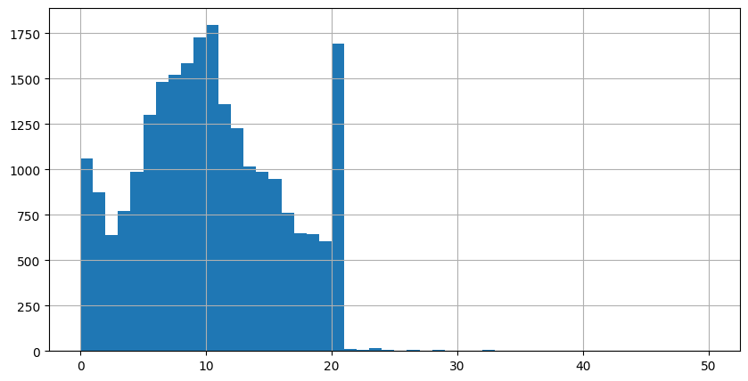

```python
# Построим гистограмму для столбца total_images
data['total_images'].hist(bins=50, figsize=(10, 5));
```

```python
# Посчитаем количество строк где фотографий от 20
len(data[(20 < data['total_images']) & (data['total_images'] < 50)])
```

```
72
```

Основном объявления недвижимости имеют количество фотографий от 10 до 20 фотографий. Данные выглядят правдоподобно. Если 72 случая - аномальные значения, считаю это допустимой погрешностью

**Рассмотрим подробнее столбец `last_price`**

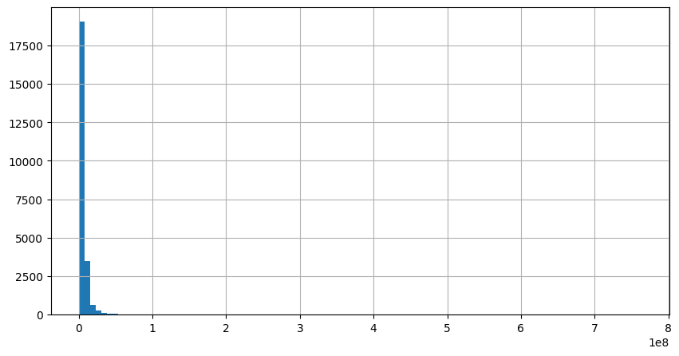

```python
data['last_price'].hist(bins=100, figsize=(10, 5));
```

```python
data['last_price'].describe() / 1000000
```

```
count      0.023699
mean       6.541549
std       10.887013
min        0.012190
25%        3.400000
50%        4.650000
75%        6.800000
max      763.000000
Name: last_price, dtype: float64
```

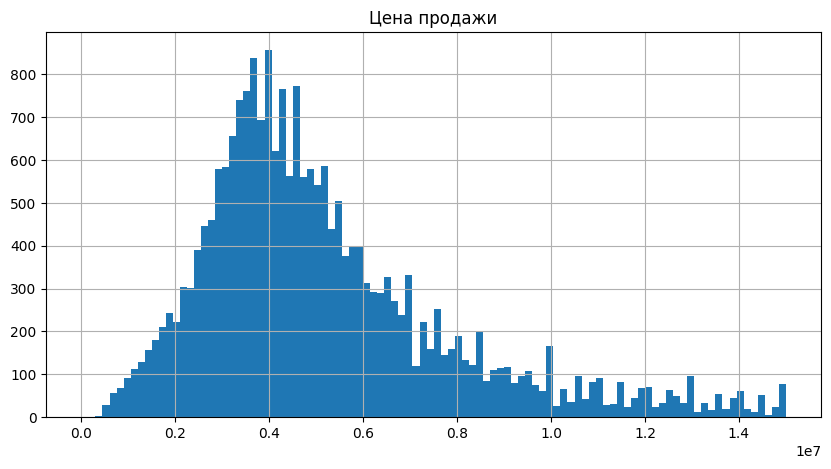

```python
data['last_price'].hist(bins=100, range=(0, 15000000), figsize=(10, 5))
plt.title('Цена продажи')
```

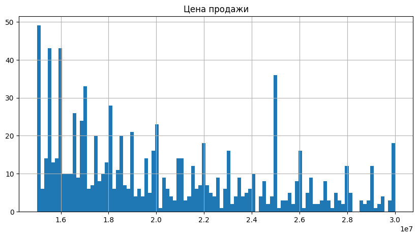

```python
data['last_price'].hist(bins=100, range=(15000000, 30000000), figsize=(10, 5))
plt.title('Цена продажи')
```

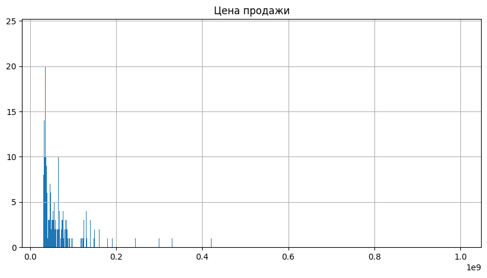

```python
data['last_price'].hist(bins=1000, range=(30000000, 1000000000), figsize=(10, 5))
plt.title('Цена продажи')
```

Самая дешевая квартира стоит 12190 рублей, а самая дорогая 763000000 рублей. Данные выглядят правдоподобно!

**Изучим столбец `total_area`**

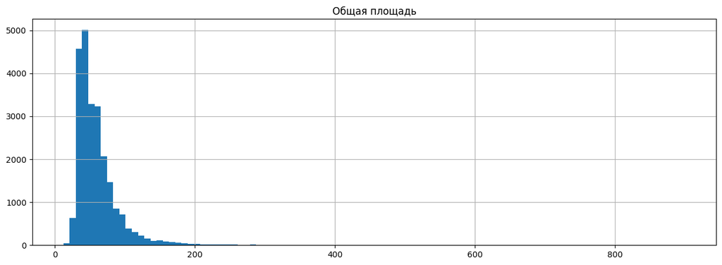

```python
data['total_area'].hist(bins=100, figsize=(15, 5))
plt.title('Общая площадь')
```

```python
data['total_area'].describe()
```

```
count    23699.000000
mean        60.348651
std         35.654083
min         12.000000
25%         40.000000
50%         52.000000
75%         69.900000
max        900.000000
Name: total_area, dtype: float64
```

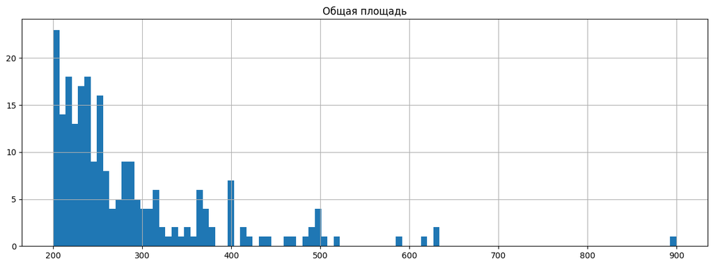

```python
data['total_area'].hist(bins=100, range=(200, 900), figsize=(15, 5))
plt.title('Общая площадь');
```

```python
# посчитаем количество строк с площадью от 200 метров в квадрате

len(data[(200 <= data['total_area']) & (data['total_area'] <= 1000)])
```

```
231
```

В целом данные выглядят правдоподобно, 231 считаю приемлемой погрешностью

**Преобразуем столбец `first_day_exposition` в datetime**

```python
# Используем метод to_datetime

data['first_day_exposition'] = pd.to_datetime(data['first_day_exposition'], format='%Y-%m-%dT%H:%M:%S')
```

```python
data['first_day_exposition'].head()
```

```
0   2019-03-07
1   2018-12-04
2   2015-08-20
3   2015-07-24
4   2018-06-19
Name: first_day_exposition, dtype: datetime64[ns]
```

Столбец принял формат datetime!

**Рассмотрим столбец `rooms`**

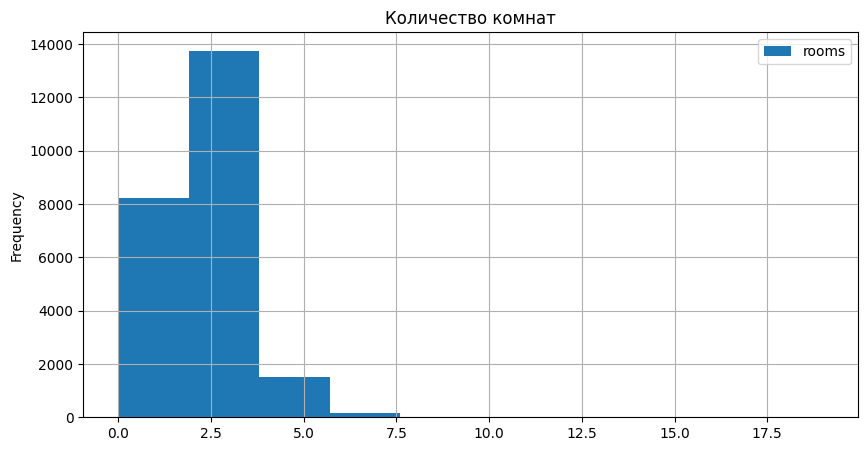

```python
data.plot(y='rooms', kind='hist', figsize=(10, 5), grid=True, title='Количество комнат');
```

```python
data['rooms'].describe()
```

```
count    23699.000000
mean         2.070636
std          1.078405
min          0.000000
25%          1.000000
50%          2.000000
75%          3.000000
max         19.000000
Name: rooms, dtype: float64
```

Изучим сколько квартир с 0 комнат, возможно это студии!

```python
# Проверим количество строк, где количество комнат 0

data.query('rooms == 0').shape[0]
```

```
197
```

Всего таких столбцов 197. Изучим сколько таких столбцов, где количество комнат равно нулю и студия равно True

```python
data.query('rooms == 0 and studio == True').shape[0]
```

```
138
```

Таких строк 138, можно прийти к итогу, что 138 строк это студии. А остальную часть, раcсмотрим подробнее

```python
display(data.query('rooms == 0 and studio == False').head())
data.query('rooms == 0 and studio == False').tail()
```

|  | total_images | last_price | total_area | first_day_exposition | rooms | ceiling_height | floors_total | living_area | floor | is_apartment | studio | open_plan | kitchen_area | balcony | locality_name | airports_nearest | city_centers_nearest | parks_around3000 | parks_nearest | ponds_around3000 | ponds_nearest | days_exposition |
| --- | --- | --- | --- | --- | --- | --- | --- | --- | --- | --- | --- | --- | --- | --- | --- | --- | --- | --- | --- | --- | --- | --- |
| 349 | 4 | 2320000.0 | 25.0 | 2017-09-27 | 0 | NaN | 14.0 | 17.0 | 1 | NaN | False | True | NaN | 0.0 | деревня Кудрово | NaN | NaN | NaN | NaN | NaN | NaN | 45.0 |
| 508 | 0 | 3375000.0 | 34.4 | 2017-03-28 | 0 | NaN | 26.0 | 24.3 | 19 | NaN | False | True | NaN | 1.0 | посёлок Парголово | 53115.0 | 19292.0 | 0.0 | NaN | 1.0 | 593.0 | 430.0 |
| 780 | 9 | 2600000.0 | 26.1 | 2018-02-20 | 0 | NaN | 18.0 | NaN | 8 | NaN | False | True | NaN | 1.0 | посёлок Мурино | NaN | NaN | NaN | NaN | NaN | NaN | 45.0 |
| 839 | 14 | 1900000.0 | 35.0 | 2017-04-14 | 0 | 2.7 | 5.0 | 15.0 | 3 | False | False | True | NaN | 1.0 | поселок Новый Свет | NaN | NaN | NaN | NaN | NaN | NaN | 7.0 |
| 946 | 5 | 2200000.0 | 23.0 | 2016-09-27 | 0 | NaN | 27.0 | 18.0 | 7 | NaN | False | True | NaN | 2.0 | посёлок Мурино | NaN | NaN | NaN | NaN | NaN | NaN | 483.0 |

|  | total_images | last_price | total_area | first_day_exposition | rooms | ceiling_height | floors_total | living_area | floor | is_apartment | studio | open_plan | kitchen_area | balcony | locality_name | airports_nearest | city_centers_nearest | parks_around3000 | parks_nearest | ponds_around3000 | ponds_nearest | days_exposition |
| --- | --- | --- | --- | --- | --- | --- | --- | --- | --- | --- | --- | --- | --- | --- | --- | --- | --- | --- | --- | --- | --- | --- |
| 21299 | 13 | 2450000.0 | 28.5 | 2017-11-22 | 0 | NaN | 12.0 | 18.0 | 7 | NaN | False | True | NaN | 2.0 | Санкт-Петербург | 20381.0 | 19383.0 | 0.0 | NaN | 1.0 | 579.0 | 73.0 |
| 21628 | 9 | 3900000.0 | 34.0 | 2017-03-18 | 0 | NaN | 20.0 | 24.0 | 10 | NaN | False | True | NaN | 2.0 | Санкт-Петербург | 15506.0 | 13615.0 | 0.0 | NaN | 1.0 | 767.0 | 320.0 |
| 22573 | 8 | 2250000.0 | 24.0 | 2017-09-28 | 0 | NaN | 12.0 | 15.0 | 3 | NaN | False | True | NaN | 2.0 | городской посёлок Новоселье | NaN | NaN | NaN | NaN | NaN | NaN | 45.0 |
| 23442 | 0 | 2500000.0 | 27.7 | 2017-09-28 | 0 | NaN | 24.0 | 18.0 | 4 | NaN | False | True | NaN | 2.0 | посёлок Мурино | NaN | NaN | NaN | NaN | NaN | NaN | 4.0 |
| 23592 | 10 | 1450000.0 | 29.0 | 2017-11-11 | 0 | NaN | 9.0 | 18.0 | 8 | NaN | False | True | NaN | 2.0 | Никольское | NaN | NaN | NaN | NaN | NaN | NaN | 82.0 |

По выведенным строки можно сказать, что часть строк также могу являться студиями. Так как общая площадь квартир зачастую не превышает 30 кв. метров.

```python
# Изучим строки с количеством комнат подробнее, отсортировав их по площади.

data.query('rooms == 0 and studio == False')['total_area'].describe()
```

```
count     59.000000
mean      32.707288
std       44.986261
min       16.000000
25%       25.000000
50%       26.100000
75%       28.250000
max      371.000000
Name: total_area, dtype: float64
```

Часть квартир с площадью меньше 30 переведем в квартиры - судии.

```python
data.loc[(data['rooms'] == 0) & (data['studio'] == False) & (data['total_area'] <= 30), 'studio'] = True
```

```python
# Проведем проверку замены
data.query('rooms == 0 and studio == True').shape[0]
```

```
187
```

Изучим строки, где площадь квартиры больше, 30 кв. метров.

```python
data.query('rooms == 0 and studio == False and total_area >= 30')
```

|  | total_images | last_price | total_area | first_day_exposition | rooms | ceiling_height | floors_total | living_area | floor | is_apartment | studio | open_plan | kitchen_area | balcony | locality_name | airports_nearest | city_centers_nearest | parks_around3000 | parks_nearest | ponds_around3000 | ponds_nearest | days_exposition |
| --- | --- | --- | --- | --- | --- | --- | --- | --- | --- | --- | --- | --- | --- | --- | --- | --- | --- | --- | --- | --- | --- | --- |
| 508 | 0 | 3375000.0 | 34.40 | 2017-03-28 | 0 | NaN | 26.0 | 24.3 | 19 | NaN | False | True | NaN | 1.0 | посёлок Парголово | 53115.0 | 19292.0 | 0.0 | NaN | 1.0 | 593.0 | 430.0 |
| 839 | 14 | 1900000.0 | 35.00 | 2017-04-14 | 0 | 2.70 | 5.0 | 15.0 | 3 | False | False | True | NaN | 1.0 | поселок Новый Свет | NaN | NaN | NaN | NaN | NaN | NaN | 7.0 |
| 4683 | 2 | 3650000.0 | 35.00 | 2018-02-01 | 0 | NaN | 25.0 | 23.4 | 25 | NaN | False | True | NaN | NaN | Санкт-Петербург | 43431.0 | 12188.0 | 0.0 | NaN | 0.0 | NaN | 100.0 |
| 6805 | 7 | 1850000.0 | 31.00 | 2017-11-10 | 0 | NaN | 18.0 | 18.0 | 10 | NaN | False | True | NaN | 1.0 | Никольское | NaN | NaN | NaN | NaN | NaN | NaN | 7.0 |
| 7008 | 4 | 5200000.0 | 32.30 | 2017-09-14 | 0 | NaN | 11.0 | 25.5 | 4 | NaN | False | True | NaN | NaN | Санкт-Петербург | 30824.0 | 6469.0 | 1.0 | 756.0 | 1.0 | 936.0 | 86.0 |
| 7237 | 8 | 2999000.0 | 42.63 | 2017-11-27 | 0 | NaN | 16.0 | 25.7 | 2 | NaN | False | True | NaN | 2.0 | деревня Кудрово | NaN | NaN | NaN | NaN | NaN | NaN | 45.0 |
| 17805 | 17 | 2600000.0 | 31.10 | 2017-10-25 | 0 | NaN | 16.0 | 21.4 | 14 | NaN | False | True | NaN | 2.0 | Санкт-Петербург | 19212.0 | 22637.0 | 0.0 | NaN | 1.0 | 457.0 | 44.0 |
| 19392 | 5 | 71000000.0 | 371.00 | 2018-07-26 | 0 | 3.57 | 7.0 | NaN | 6 | NaN | False | True | NaN | NaN | Санкт-Петербург | 25257.0 | 6060.0 | 1.0 | 761.0 | 1.0 | 584.0 | 90.0 |
| 19735 | 1 | 2800000.0 | 30.50 | 2017-10-10 | 0 | 2.75 | 25.0 | 20.0 | 2 | NaN | False | True | NaN | 2.0 | деревня Кудрово | NaN | NaN | NaN | NaN | NaN | NaN | 13.0 |
| 21628 | 9 | 3900000.0 | 34.00 | 2017-03-18 | 0 | NaN | 20.0 | 24.0 | 10 | NaN | False | True | NaN | 2.0 | Санкт-Петербург | 15506.0 | 13615.0 | 0.0 | NaN | 1.0 | 767.0 | 320.0 |

9 столбцов из 10 определим в 1 комнатные квартиры. Квартиру с площадью 371 кв. метров пока оставим в покое.

```python
data.loc[(data['rooms'] == 0) & (data['studio'] == False) & (data['total_area'] >= 30) & (data['total_area'] != 371), 'rooms'] = 1
```

```python
data.query('rooms == 0 and studio == False and total_area >= 30')
```

|  | total_images | last_price | total_area | first_day_exposition | rooms | ceiling_height | floors_total | living_area | floor | is_apartment | studio | open_plan | kitchen_area | balcony | locality_name | airports_nearest | city_centers_nearest | parks_around3000 | parks_nearest | ponds_around3000 | ponds_nearest | days_exposition |
| --- | --- | --- | --- | --- | --- | --- | --- | --- | --- | --- | --- | --- | --- | --- | --- | --- | --- | --- | --- | --- | --- | --- |
| 19392 | 5 | 71000000.0 | 371.0 | 2018-07-26 | 0 | 3.57 | 7.0 | NaN | 6 | NaN | False | True | NaN | NaN | Санкт-Петербург | 25257.0 | 6060.0 | 1.0 | 761.0 | 1.0 | 584.0 | 90.0 |

**Обработаем `ceiling_height`**

Столбец - высота потолков имеет пропуски, количество пропусков - 9195

```python
data['ceiling_height'].describe()
```

```
count    14504.000000
mean         2.771499
std          1.261056
min          1.000000
25%          2.520000
50%          2.650000
75%          2.800000
max        100.000000
Name: ceiling_height, dtype: float64
```

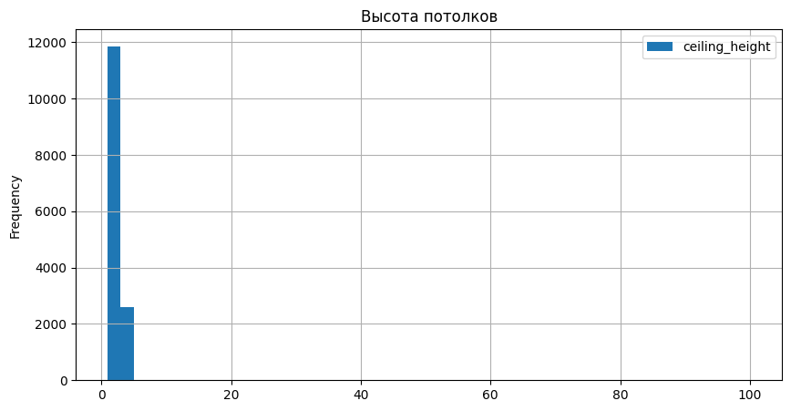

```python
data.plot(y='ceiling_height', kind='hist', bins=50, figsize=(10, 5), grid=True, title='Высота потолков');
```

```python
# Заменим пропуски медианным значением высоты потолков
median_ceiling_height = data['ceiling_height'].median()
data.loc[data['ceiling_height'].isna(), 'ceiling_height'] = median_ceiling_height
```

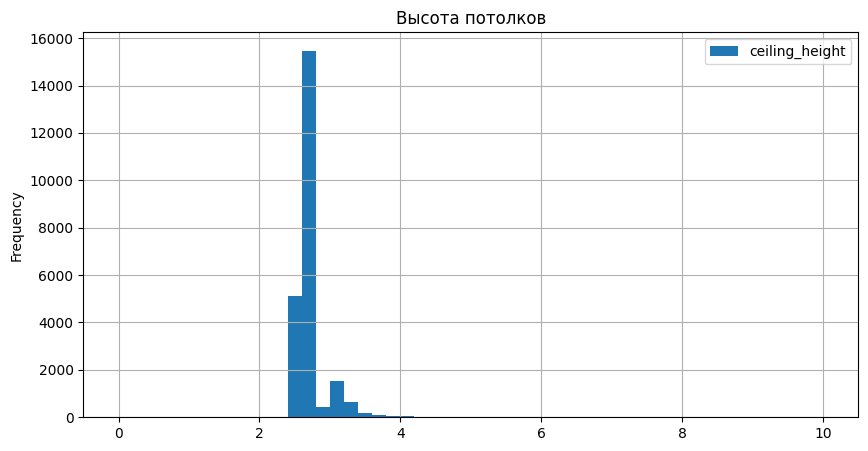

```python
data.plot(y='ceiling_height', kind='hist', bins=50, range=(0, 10), figsize=(10, 5), grid=True, title='Высота потолков');
```

Замена прошла успешно

**Изучим `floors_total`**

Столбец, всего этажей имеет 86 пропусков, считаю это число незначительным.

```python
data['floors_total'].describe()
```

```
count    23613.000000
mean        10.673824
std          6.597173
min          1.000000
25%          5.000000
50%          9.000000
75%         16.000000
max         60.000000
Name: floors_total, dtype: float64
```

```python
# Ознакомимся с пропусками
data[data['floors_total'].isna()].head(10)
```

|  | total_images | last_price | total_area | first_day_exposition | rooms | ceiling_height | floors_total | living_area | floor | is_apartment | studio | open_plan | kitchen_area | balcony | locality_name | airports_nearest | city_centers_nearest | parks_around3000 | parks_nearest | ponds_around3000 | ponds_nearest | days_exposition |
| --- | --- | --- | --- | --- | --- | --- | --- | --- | --- | --- | --- | --- | --- | --- | --- | --- | --- | --- | --- | --- | --- | --- |
| 186 | 12 | 11640000.0 | 65.20 | 2018-10-02 | 2 | 2.65 | NaN | 30.80 | 4 | NaN | False | False | 12.00 | NaN | Санкт-Петербург | 39197.0 | 12373.0 | 1.0 | 123.0 | 0.0 | NaN | 49.0 |
| 237 | 4 | 2438033.0 | 28.10 | 2016-11-23 | 1 | 2.65 | NaN | 20.75 | 1 | NaN | False | False | NaN | 0.0 | Санкт-Петербург | 22041.0 | 17369.0 | 0.0 | NaN | 1.0 | 374.0 | 251.0 |
| 457 | 4 | 9788348.0 | 70.80 | 2015-08-01 | 2 | 2.65 | NaN | 38.40 | 12 | NaN | False | False | 10.63 | 0.0 | Санкт-Петербург | 37364.0 | 8322.0 | 2.0 | 309.0 | 2.0 | 706.0 | 727.0 |
| 671 | 4 | 6051191.0 | 93.60 | 2017-04-06 | 3 | 2.65 | NaN | 47.10 | 8 | NaN | False | False | 16.80 | 0.0 | Санкт-Петербург | 22041.0 | 17369.0 | 0.0 | NaN | 1.0 | 374.0 | 123.0 |
| 1757 | 5 | 3600000.0 | 39.00 | 2017-04-22 | 1 | 2.65 | NaN | NaN | 9 | NaN | False | False | NaN | 0.0 | Санкт-Петербург | 22735.0 | 11618.0 | 1.0 | 835.0 | 1.0 | 652.0 | 77.0 |
| 1930 | 1 | 9750000.0 | 66.77 | 2016-05-13 | 2 | 2.65 | NaN | NaN | 4 | NaN | False | False | NaN | 0.0 | Санкт-Петербург | 39886.0 | 10660.0 | 1.0 | 2276.0 | 3.0 | 244.0 | 90.0 |
| 2392 | 7 | 5395770.0 | 53.00 | 2017-06-29 | 2 | 2.65 | NaN | 29.00 | 22 | NaN | False | False | 9.00 | 0.0 | Санкт-Петербург | 43074.0 | 10820.0 | 0.0 | NaN | 0.0 | NaN | 48.0 |
| 2846 | 4 | 2325000.0 | 27.80 | 2016-09-21 | 1 | 2.65 | NaN | 19.40 | 15 | NaN | False | False | NaN | 0.0 | Санкт-Петербург | 22041.0 | 17369.0 | 0.0 | NaN | 1.0 | 374.0 | 307.0 |
| 2952 | 10 | 6500000.0 | 54.30 | 2019-04-23 | 1 | 2.65 | NaN | 22.20 | 6 | NaN | False | False | 12.30 | NaN | Санкт-Петербург | 23606.0 | 3148.0 | 0.0 | NaN | 0.0 | NaN | NaN |
| 3031 | 9 | 6400000.0 | 56.70 | 2018-03-27 | 2 | 2.65 | NaN | 32.00 | 12 | NaN | False | False | 12.00 | NaN | Кудрово | NaN | NaN | NaN | NaN | NaN | NaN | 231.0 |

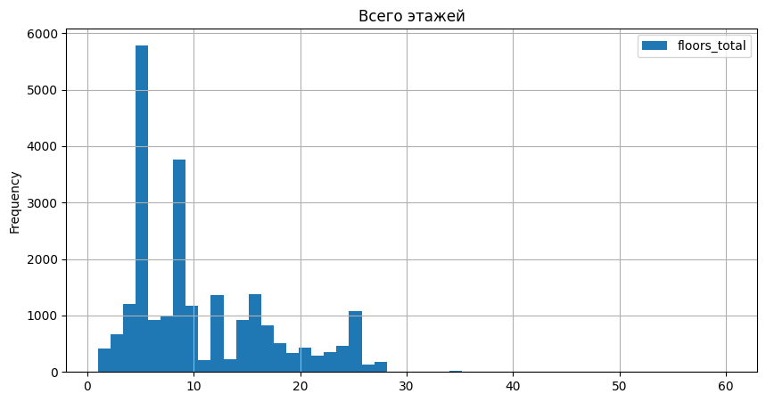

```python
data.plot(y='floors_total', kind='hist', bins=50, figsize=(10, 5), grid=True, title='Всего этажей');
```

Аномальных значений не наблюдаю

```python
# Удалим пропуски в столбце floors_total
data.dropna(subset=['floors_total'], inplace=True)
```

```python
# Переведем значения в столбце floors_total в int

data['floors_total'] = data['floors_total'].astype('int')
data['floors_total'].head()
```

```
0    16
1    11
2     5
3    14
4    14
Name: floors_total, dtype: int64
```

**Обработаем столбец `living_area`**

Столбец жилая площадь в квадратных метрах (м²) имеет - 1903 пропуска

```python
data['living_area'].describe()
```

```
count    21743.000000
mean        34.462781
std         22.037433
min          2.000000
25%         18.600000
50%         30.000000
75%         42.300000
max        409.700000
Name: living_area, dtype: float64
```

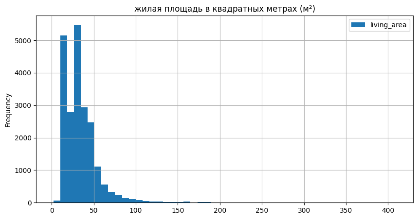

```python
data.plot(y='living_area', kind='hist', bins=50, figsize=(10, 5), grid=True, title='жилая площадь в квадратных метрах (м²)');
```

Квартира с жилой площадью 2 м² выглядит странно. По данным на 2024 год, минимальный размер студий должен быть не меньше 28 м²

```python
# Проверим сколько квартир с жилой площадью меньше 2 м²

display(data.query('living_area <=2'))
```

|  | total_images | last_price | total_area | first_day_exposition | rooms | ceiling_height | floors_total | living_area | floor | is_apartment | studio | open_plan | kitchen_area | balcony | locality_name | airports_nearest | city_centers_nearest | parks_around3000 | parks_nearest | ponds_around3000 | ponds_nearest | days_exposition |
| --- | --- | --- | --- | --- | --- | --- | --- | --- | --- | --- | --- | --- | --- | --- | --- | --- | --- | --- | --- | --- | --- | --- |
| 13915 | 20 | 6350000.0 | 52.0 | 2018-02-06 | 2 | 3.00 | 6 | 2.0 | 2 | NaN | False | False | 9.0 | NaN | Санкт-Петербург | 32453.0 | 6521.0 | 0.0 | NaN | 1.0 | 1012.0 | 91.0 |
| 21758 | 0 | 2330000.0 | 23.0 | 2018-01-01 | 0 | 2.65 | 24 | 2.0 | 22 | NaN | True | False | NaN | NaN | посёлок Мурино | NaN | NaN | NaN | NaN | NaN | NaN | 66.0 |

Природа такого явления не понятна, оставим как есть, чтобы сохранить данные

```python
data[['total_area', 'living_area']].head(20)
```

|  | total_area | living_area |
| --- | --- | --- |
| 0 | 108.00 | 51.00 |
| 1 | 40.40 | 18.60 |
| 2 | 56.00 | 34.30 |
| 3 | 159.00 | NaN |
| 4 | 100.00 | 32.00 |
| 5 | 30.40 | 14.40 |
| 6 | 37.30 | 10.60 |
| 7 | 71.60 | NaN |
| 8 | 33.16 | 15.43 |
| 9 | 61.00 | 43.60 |
| 10 | 39.60 | 20.30 |
| 11 | 44.00 | 31.00 |
| 12 | 54.00 | 30.00 |
| 13 | 42.80 | 27.00 |
| 14 | 36.00 | 17.00 |
| 15 | 39.00 | 20.50 |
| 16 | 82.00 | 55.60 |
| 17 | 36.00 | 16.50 |
| 18 | 31.00 | 19.40 |
| 19 | 121.00 | 76.00 |

Жилая площадь — это сумма площадей жилых комнат в квартире. К ним относятся спальня, гостиная, детская, кабинет. По этой причине думаю заменить пропуски половиной от общей площади квартиры.

```python
# Заменяем пропуски в 'living_area' используя lambda-функцию
data['living_area'] = data['living_area'].fillna(data['total_area'].map(lambda x: x / 2))

# Проверим замену в датафрейме
data[['total_area', 'living_area']].head(20)
```

|  | total_area | living_area |
| --- | --- | --- |
| 0 | 108.00 | 51.00 |
| 1 | 40.40 | 18.60 |
| 2 | 56.00 | 34.30 |
| 3 | 159.00 | 79.50 |
| 4 | 100.00 | 32.00 |
| 5 | 30.40 | 14.40 |
| 6 | 37.30 | 10.60 |
| 7 | 71.60 | 35.80 |
| 8 | 33.16 | 15.43 |
| 9 | 61.00 | 43.60 |
| 10 | 39.60 | 20.30 |
| 11 | 44.00 | 31.00 |
| 12 | 54.00 | 30.00 |
| 13 | 42.80 | 27.00 |
| 14 | 36.00 | 17.00 |
| 15 | 39.00 | 20.50 |
| 16 | 82.00 | 55.60 |
| 17 | 36.00 | 16.50 |
| 18 | 31.00 | 19.40 |
| 19 | 121.00 | 76.00 |

**Обработаем `is_apartment` и `kitchen_area`**

В столбце is_aparment 20890 пропусков и он булевой тип. Есть предположение, что люди могли просто не заполнить данный столбец, если квартира не студия. Заполнение пропусков в столбце буду выполнять отталкиваясь от столбца kitchen_area, если kitchen_area = NaN, то is_aparment = True, иное is_aparment = False. Такая замена предполагает, что пропуски в столбце is_aparment можно заменить по данным кухни, так как в студии кухня совмещена с жилой комнатой.

```python
# Заполнение пропусков в is_apartment на основе kitchen_area
data.loc[data['kitchen_area'].isna(), 'is_apartment'] = True
data.loc[data['kitchen_area'].notna(), 'is_apartment'] = False

data['is_apartment'].head(20)
```

```
0     False
1     False
2     False
3      True
4     False
5     False
6     False
7     False
8     False
9     False
10    False
11    False
12    False
13    False
14    False
15    False
16    False
17    False
18    False
19    False
Name: is_apartment, dtype: object
```

```python
# Заменим тип данных в столбце на bool
data['is_apartment'] = data['is_apartment'].astype('bool')
```

Заменим пропуски в столбце kitchen_area

```python
# Для замены пропусков вычислим средний коэффициент отношения площади кухни к общей площади
kitchen_area_coeff = (data['kitchen_area'] / data['total_area']).mean()
```

```python
# Заполняем пропуски в 'kitchen_area' на основе среднего коэффициента
data['kitchen_area'] = data['kitchen_area'].fillna(kitchen_area_coeff * data['total_area'])
data.info()
```

```
<class 'pandas.core.frame.DataFrame'>
Index: 23613 entries, 0 to 23698
Data columns (total 22 columns):
 #   Column                Non-Null Count  Dtype
---  ------                --------------  -----
 0   total_images          23613 non-null  int64
 1   last_price            23613 non-null  float64
 2   total_area            23613 non-null  float64
 3   first_day_exposition  23613 non-null  datetime64[ns]
 4   rooms                 23613 non-null  int64
 5   ceiling_height        23613 non-null  float64
 6   floors_total          23613 non-null  int64
 7   living_area           23613 non-null  float64
 8   floor                 23613 non-null  int64
 9   is_apartment          23613 non-null  bool
 10  studio                23613 non-null  bool
 11  open_plan             23613 non-null  bool
 12  kitchen_area          23613 non-null  float64
 13  balcony               12133 non-null  float64
 14  locality_name         23565 non-null  object
 15  airports_nearest      18081 non-null  float64
 16  city_centers_nearest  18104 non-null  float64
 17  parks_around3000      18105 non-null  float64
 18  parks_nearest         8045 non-null   float64
 19  ponds_around3000      18105 non-null  float64
 20  ponds_nearest         9061 non-null   float64
 21  days_exposition       20441 non-null  float64
dtypes: bool(3), datetime64[ns](1), float64(13), int64(4), object(1)
memory usage: 3.7+ MB
```

**Расмотрим столбец `balcony`**

Количество пропусков в столбце - 11519. Есть предположение, что количество пропусков зависит от наличия балкона, если он отсутствует значит люди не заполняли данный столбец.

```python
# Осуществляем замену пропусков 0
data['balcony'] = data['balcony'].fillna(0)
data['balcony'].isna().sum()
```

```
np.int64(0)
```

```python
data.isna().sum()
```

```
total_images                0
last_price                  0
total_area                  0
first_day_exposition        0
rooms                       0
ceiling_height              0
floors_total                0
living_area                 0
floor                       0
is_apartment                0
studio                      0
open_plan                   0
kitchen_area                0
balcony                     0
locality_name              48
airports_nearest         5532
city_centers_nearest     5509
parks_around3000         5508
parks_nearest           15568
ponds_around3000         5508
ponds_nearest           14552
days_exposition          3172
dtype: int64
```

**Обработаем столбец `locality_name`**

```python
# Обработаем неявные дубликаты в столбце
data['locality_name'].sort_values().unique()
```

```
array(['Бокситогорск', 'Волосово', 'Волхов', 'Всеволожск', 'Выборг',
       'Высоцк', 'Гатчина', 'Зеленогорск', 'Ивангород', 'Каменногорск',
       'Кингисепп', 'Кириши', 'Кировск', 'Колпино', 'Коммунар',
       'Красное Село', 'Кронштадт', 'Кудрово', 'Лодейное Поле',
       'Ломоносов', 'Луга', 'Любань', 'Мурино', 'Никольское',
       'Новая Ладога', 'Отрадное', 'Павловск', 'Петергоф', 'Пикалёво',
       'Подпорожье', 'Приморск', 'Приозерск', 'Пушкин', 'Санкт-Петербург',
       'Светогорск', 'Сертолово', 'Сестрорецк', 'Сланцы', 'Сосновый Бор',
       'Сясьстрой', 'Тихвин', 'Тосно', 'Шлиссельбург',
       'городской поселок Большая Ижора', 'городской поселок Янино-1',
       'городской посёлок Будогощь', 'городской посёлок Виллози',
       'городской посёлок Лесогорский', 'городской посёлок Мга',
       'городской посёлок Назия', 'городской посёлок Новоселье',
       'городской посёлок Павлово', 'городской посёлок Рощино',
       'городской посёлок Свирьстрой', 'городской посёлок Советский',
       'городской посёлок Фёдоровское', 'городской посёлок Янино-1',
       'деревня Агалатово', 'деревня Аро', 'деревня Батово',
       'деревня Бегуницы', 'деревня Белогорка', 'деревня Большая Вруда',
       'деревня Большая Пустомержа', 'деревня Большие Колпаны',
       'деревня Большое Рейзино', 'деревня Большой Сабск', 'деревня Бор',
       'деревня Борисова Грива', 'деревня Ваганово', 'деревня Вартемяги',
       'деревня Вахнова Кара', 'деревня Выскатка', 'деревня Гарболово',
       'деревня Глинка', 'деревня Горбунки', 'деревня Гостилицы',
       'деревня Заклинье', 'деревня Заневка', 'деревня Зимитицы',
       'деревня Извара', 'деревня Иссад', 'деревня Калитино',
       'деревня Кальтино', 'деревня Камышовка', 'деревня Каськово',
       'деревня Келози', 'деревня Кипень', 'деревня Кисельня',
       'деревня Колтуши', 'деревня Коркино', 'деревня Котлы',
       'деревня Кривко', 'деревня Кудрово', 'деревня Кузьмолово',
       'деревня Курковицы', 'деревня Куровицы', 'деревня Куттузи',
       'деревня Лаврики', 'деревня Лаголово', 'деревня Лампово',
       'деревня Лесколово', 'деревня Лопухинка', 'деревня Лупполово',
       'деревня Малая Романовка', 'деревня Малое Верево',
       'деревня Малое Карлино', 'деревня Малые Колпаны',
       'деревня Мануйлово', 'деревня Меньково', 'деревня Мины',
       'деревня Мистолово', 'деревня Ненимяки', 'деревня Нижние Осельки',
       'деревня Нижняя', 'деревня Низино', 'деревня Новое Девяткино',
       'деревня Новолисино', 'деревня Нурма', 'деревня Оржицы',
       'деревня Парицы', 'деревня Пельгора', 'деревня Пеники',
       'деревня Пижма', 'деревня Пикколово', 'деревня Пудомяги',
```

[output cut: 96 more lines]

```
       'посёлок городского типа Тайцы', 'посёлок городского типа Токсово',
       'посёлок городского типа Ульяновка',
       'посёлок городского типа Форносово',
       'посёлок городского типа имени Морозова',
       'посёлок городского типа имени Свердлова',
       'посёлок при железнодорожной станции Вещево',
       'посёлок при железнодорожной станции Приветнинское',
       'посёлок станции Громово', 'посёлок станции Свирь',
       'садоводческое некоммерческое товарищество Лесная Поляна',
       'садовое товарищество Новая Ропша',
       'садовое товарищество Приладожский', 'садовое товарищество Рахья',
       'садовое товарищество Садко', 'село Копорье', 'село Никольское',
       'село Павлово', 'село Паша', 'село Путилово', 'село Рождествено',
       'село Русско-Высоцкое', 'село Старая Ладога', 'село Шум', nan],
      dtype=object)
```

```python
data['locality_name'] = (data['locality_name'].str
                         .replace('ё', 'е')
                         .replace(['поселок городского типа ', 'городской поселок '], 'поселок ', regex=True))

data['locality_name'].sort_values().unique()
```

```
array(['Бокситогорск', 'Волосово', 'Волхов', 'Всеволожск', 'Выборг',
       'Высоцк', 'Гатчина', 'Зеленогорск', 'Ивангород', 'Каменногорск',
       'Кингисепп', 'Кириши', 'Кировск', 'Колпино', 'Коммунар',
       'Красное Село', 'Кронштадт', 'Кудрово', 'Лодейное Поле',
       'Ломоносов', 'Луга', 'Любань', 'Мурино', 'Никольское',
       'Новая Ладога', 'Отрадное', 'Павловск', 'Петергоф', 'Пикалево',
       'Подпорожье', 'Приморск', 'Приозерск', 'Пушкин', 'Санкт-Петербург',
       'Светогорск', 'Сертолово', 'Сестрорецк', 'Сланцы', 'Сосновый Бор',
       'Сясьстрой', 'Тихвин', 'Тосно', 'Шлиссельбург',
       'деревня Агалатово', 'деревня Аро', 'деревня Батово',
       'деревня Бегуницы', 'деревня Белогорка', 'деревня Большая Вруда',
       'деревня Большая Пустомержа', 'деревня Большие Колпаны',
       'деревня Большое Рейзино', 'деревня Большой Сабск', 'деревня Бор',
       'деревня Борисова Грива', 'деревня Ваганово', 'деревня Вартемяги',
       'деревня Вахнова Кара', 'деревня Выскатка', 'деревня Гарболово',
       'деревня Глинка', 'деревня Горбунки', 'деревня Гостилицы',
       'деревня Заклинье', 'деревня Заневка', 'деревня Зимитицы',
       'деревня Извара', 'деревня Иссад', 'деревня Калитино',
       'деревня Кальтино', 'деревня Камышовка', 'деревня Каськово',
       'деревня Келози', 'деревня Кипень', 'деревня Кисельня',
       'деревня Колтуши', 'деревня Коркино', 'деревня Котлы',
       'деревня Кривко', 'деревня Кудрово', 'деревня Кузьмолово',
       'деревня Курковицы', 'деревня Куровицы', 'деревня Куттузи',
       'деревня Лаврики', 'деревня Лаголово', 'деревня Лампово',
       'деревня Лесколово', 'деревня Лопухинка', 'деревня Лупполово',
       'деревня Малая Романовка', 'деревня Малое Верево',
       'деревня Малое Карлино', 'деревня Малые Колпаны',
       'деревня Мануйлово', 'деревня Меньково', 'деревня Мины',
       'деревня Мистолово', 'деревня Ненимяки', 'деревня Нижние Осельки',
       'деревня Нижняя', 'деревня Низино', 'деревня Новое Девяткино',
       'деревня Новолисино', 'деревня Нурма', 'деревня Оржицы',
       'деревня Парицы', 'деревня Пельгора', 'деревня Пеники',
       'деревня Пижма', 'деревня Пикколово', 'деревня Пудомяги',
       'деревня Пустынка', 'деревня Пчева', 'деревня Рабитицы',
       'деревня Разбегаево', 'деревня Раздолье', 'деревня Разметелево',
       'деревня Рапполово', 'деревня Реброво', 'деревня Русско',
       'деревня Сижно', 'деревня Снегиревка', 'деревня Старая',
       'деревня Старая Пустошь', 'деревня Старое Хинколово',
       'деревня Старополье', 'деревня Старосиверская',
       'деревня Старые Бегуницы', 'деревня Суоранда',
```

[output cut: 58 more lines]

```
       'поселок Цвылево', 'поселок Шугозеро', 'поселок Шушары',
       'поселок Щеглово', 'поселок Янино-1', 'поселок имени Морозова',
       'поселок имени Свердлова',
       'поселок при железнодорожной станции Вещево',
       'поселок при железнодорожной станции Приветнинское',
       'поселок станции Вещево', 'поселок станции Громово',
       'поселок станции Корнево', 'поселок станции Лужайка',
       'поселок станции Приветнинское', 'поселок станции Свирь',
       'садоводческое некоммерческое товарищество Лесная Поляна',
       'садовое товарищество Новая Ропша',
       'садовое товарищество Приладожский', 'садовое товарищество Рахья',
       'садовое товарищество Садко', 'село Копорье', 'село Никольское',
       'село Павлово', 'село Паша', 'село Путилово', 'село Рождествено',
       'село Русско-Высоцкое', 'село Старая Ладога', 'село Шум', nan],
      dtype=object)
```

Обработка 'city_centers_nearest', 'parks_around3000', 'parks_nearest', 'ponds_around3000', 'ponds_nearest', 'days_exposition' нецелесообразна из за возможности сильно исказить данные при заполнении пропусков

Проверка на наличие дубликатов

```python
# Проверку осуществим методом duplicated
data.duplicated().sum()
```

```
np.int64(0)
```

## Добавление новыех столбцов

```python
# Добавление цены квадратного метра
data['square_meter_price'] = data['last_price']/data['total_area'].round(decimals=2) # Параметр decimals отвечает за округление
```

```python
# Определим день публикации объявления
data['week_day'] = data['first_day_exposition'].dt.weekday
```

```python
# Определим месяц публикации объявления
data['month'] = data['first_day_exposition'].dt.month
```

```python
# Определим год публикации объявления
data['year'] = data['first_day_exposition'].dt.year
```

```python
# Выведем результат добавления на экран
display(data[['first_day_exposition','week_day', 'month', 'year']].head(10))
```

|  | first_day_exposition | week_day | month | year |
| --- | --- | --- | --- | --- |
| 0 | 2019-03-07 | 3 | 3 | 2019 |
| 1 | 2018-12-04 | 1 | 12 | 2018 |
| 2 | 2015-08-20 | 3 | 8 | 2015 |
| 3 | 2015-07-24 | 4 | 7 | 2015 |
| 4 | 2018-06-19 | 1 | 6 | 2018 |
| 5 | 2018-09-10 | 0 | 9 | 2018 |
| 6 | 2017-11-02 | 3 | 11 | 2017 |
| 7 | 2019-04-18 | 3 | 4 | 2019 |
| 8 | 2018-05-23 | 2 | 5 | 2018 |
| 9 | 2017-02-26 | 6 | 2 | 2017 |

**Добавление типа этажа квартиры (значения — «первый», «последний», «другой»)**

```python
def floor_category(row):
    if row['floor'] == 1:
        return 'первый'
    elif row['floor'] == row['floors_total']:
        return 'последний'
    else:
        return 'другой'
data['floor_category'] = data.apply(floor_category, axis=1)
```

```python
data[['floors_total', 'floor', 'floor_category']].head(15)
```

|  | floors_total | floor | floor_category |
| --- | --- | --- | --- |
| 0 | 16 | 8 | другой |
| 1 | 11 | 1 | первый |
| 2 | 5 | 4 | другой |
| 3 | 14 | 9 | другой |
| 4 | 14 | 13 | другой |
| 5 | 12 | 5 | другой |
| 6 | 26 | 6 | другой |
| 7 | 24 | 22 | другой |
| 8 | 27 | 26 | другой |
| 9 | 9 | 7 | другой |
| 10 | 12 | 3 | другой |
| 11 | 5 | 4 | другой |
| 12 | 5 | 5 | последний |
| 13 | 5 | 5 | последний |
| 14 | 6 | 1 | первый |

**Добавление расстояния до центра города в километрах**

```python
data['city_centers_nearest_km'] = (data['city_centers_nearest'] / 1000).round(0)
```

```python
data[['city_centers_nearest', 'city_centers_nearest_km']].head(10)
```

|  | city_centers_nearest | city_centers_nearest_km |
| --- | --- | --- |
| 0 | 16028.0 | 16.0 |
| 1 | 18603.0 | 19.0 |
| 2 | 13933.0 | 14.0 |
| 3 | 6800.0 | 7.0 |
| 4 | 8098.0 | 8.0 |
| 5 | NaN | NaN |
| 6 | 19143.0 | 19.0 |
| 7 | 11634.0 | 12.0 |
| 8 | NaN | NaN |
| 9 | 15008.0 | 15.0 |

## Исследовательский анализ данных

Выполним базовую проверку данных, ответим на вопросы:

- Сколько всего объявлений?
- Какие населенные пункты встречаются в базе данных?
- Какая временная выборка в базе данных?
- Какая средняя стоимость объекта недвижимости в населенном пункте?
- В каком населенном пункте больше всего объявлений?

```python
# Сколько всего объявлений?
data.shape[0]
```

```
23613
```

```python
# Какие насеянные пункты встречаются в датафрейме можно определить методом unique()
data['locality_name'].sort_values().unique()
```

```
array(['Бокситогорск', 'Волосово', 'Волхов', 'Всеволожск', 'Выборг',
       'Высоцк', 'Гатчина', 'Зеленогорск', 'Ивангород', 'Каменногорск',
       'Кингисепп', 'Кириши', 'Кировск', 'Колпино', 'Коммунар',
       'Красное Село', 'Кронштадт', 'Кудрово', 'Лодейное Поле',
       'Ломоносов', 'Луга', 'Любань', 'Мурино', 'Никольское',
       'Новая Ладога', 'Отрадное', 'Павловск', 'Петергоф', 'Пикалево',
       'Подпорожье', 'Приморск', 'Приозерск', 'Пушкин', 'Санкт-Петербург',
       'Светогорск', 'Сертолово', 'Сестрорецк', 'Сланцы', 'Сосновый Бор',
       'Сясьстрой', 'Тихвин', 'Тосно', 'Шлиссельбург',
       'деревня Агалатово', 'деревня Аро', 'деревня Батово',
       'деревня Бегуницы', 'деревня Белогорка', 'деревня Большая Вруда',
       'деревня Большая Пустомержа', 'деревня Большие Колпаны',
       'деревня Большое Рейзино', 'деревня Большой Сабск', 'деревня Бор',
       'деревня Борисова Грива', 'деревня Ваганово', 'деревня Вартемяги',
       'деревня Вахнова Кара', 'деревня Выскатка', 'деревня Гарболово',
       'деревня Глинка', 'деревня Горбунки', 'деревня Гостилицы',
       'деревня Заклинье', 'деревня Заневка', 'деревня Зимитицы',
       'деревня Извара', 'деревня Иссад', 'деревня Калитино',
       'деревня Кальтино', 'деревня Камышовка', 'деревня Каськово',
       'деревня Келози', 'деревня Кипень', 'деревня Кисельня',
       'деревня Колтуши', 'деревня Коркино', 'деревня Котлы',
       'деревня Кривко', 'деревня Кудрово', 'деревня Кузьмолово',
       'деревня Курковицы', 'деревня Куровицы', 'деревня Куттузи',
       'деревня Лаврики', 'деревня Лаголово', 'деревня Лампово',
       'деревня Лесколово', 'деревня Лопухинка', 'деревня Лупполово',
       'деревня Малая Романовка', 'деревня Малое Верево',
       'деревня Малое Карлино', 'деревня Малые Колпаны',
       'деревня Мануйлово', 'деревня Меньково', 'деревня Мины',
       'деревня Мистолово', 'деревня Ненимяки', 'деревня Нижние Осельки',
       'деревня Нижняя', 'деревня Низино', 'деревня Новое Девяткино',
       'деревня Новолисино', 'деревня Нурма', 'деревня Оржицы',
       'деревня Парицы', 'деревня Пельгора', 'деревня Пеники',
       'деревня Пижма', 'деревня Пикколово', 'деревня Пудомяги',
       'деревня Пустынка', 'деревня Пчева', 'деревня Рабитицы',
       'деревня Разбегаево', 'деревня Раздолье', 'деревня Разметелево',
       'деревня Рапполово', 'деревня Реброво', 'деревня Русско',
       'деревня Сижно', 'деревня Снегиревка', 'деревня Старая',
       'деревня Старая Пустошь', 'деревня Старое Хинколово',
       'деревня Старополье', 'деревня Старосиверская',
       'деревня Старые Бегуницы', 'деревня Суоранда',
```

[output cut: 58 more lines]

```
       'поселок Цвылево', 'поселок Шугозеро', 'поселок Шушары',
       'поселок Щеглово', 'поселок Янино-1', 'поселок имени Морозова',
       'поселок имени Свердлова',
       'поселок при железнодорожной станции Вещево',
       'поселок при железнодорожной станции Приветнинское',
       'поселок станции Вещево', 'поселок станции Громово',
       'поселок станции Корнево', 'поселок станции Лужайка',
       'поселок станции Приветнинское', 'поселок станции Свирь',
       'садоводческое некоммерческое товарищество Лесная Поляна',
       'садовое товарищество Новая Ропша',
       'садовое товарищество Приладожский', 'садовое товарищество Рахья',
       'садовое товарищество Садко', 'село Копорье', 'село Никольское',
       'село Павлово', 'село Паша', 'село Путилово', 'село Рождествено',
       'село Русско-Высоцкое', 'село Старая Ладога', 'село Шум', nan],
      dtype=object)
```

```python
# Какая временная выборка в базе данных?
print(f"Диапазон дат: от {data['first_day_exposition'].min()} до {data['first_day_exposition'].max()}")
```

```
Диапазон дат: от 2014-11-27 00:00:00 до 2019-05-03 00:00:00
```

```python
# Какая средняя стоимость объекта недвижимости в населенном пункте?
average_price = data.groupby('locality_name')['last_price'].mean().round(decimals=2)
average_price.head(40)
```

```
locality_name
Бокситогорск        846187.50
Волосово           1977777.78
Волхов             1739909.01
Всеволожск         3789067.75
Выборг             3250983.12
Высоцк             1810000.00
Гатчина            3488336.68
Зеленогорск        6288337.50
Ивангород          1486428.54
Каменногорск       1367692.31
Кингисепп          2461642.31
Кириши             1834624.00
Кировск            2749464.27
Колпино            3964021.44
Коммунар           2770921.35
Красное Село       3821852.27
Кронштадт          4132364.57
Кудрово            4566009.01
Лодейное Поле      1679000.00
Ломоносов          3662879.70
Луга               2156785.71
Любань             1677500.00
Мурино             4105287.35
Никольское         2363567.31
Новая Ладога       1978571.43
Отрадное           2837196.75
Павловск           4929710.53
Петергоф           4423840.80
Пикалево           1006666.67
Подпорожье         1420526.32
Приморск           2122500.00
Приозерск          1995075.76
Пушкин             6469035.95
Санкт-Петербург    8064895.30
Светогорск         1961818.18
Сертолово          3652432.39
Сестрорецк         6341722.08
Сланцы              873125.00
Сосновый Бор       3908129.20
Сясьстрой          1646250.00
Name: last_price, dtype: float64
```

```python
# В каком населенном пункте больше всего объявлений?

print(data['locality_name'].value_counts().head(1))
```

```
locality_name
Санкт-Петербург    15651
Name: count, dtype: int64
```

**Изучим и опишем параметры:**

- общая площадь;
- жилая площадь;
- площадь кухни;
- цена объекта;
- количество комнат;
- высота потолков;
- тип этажа квартиры («первый», «последний», «другой»);
- общее количество этажей в доме;
- расстояние до центра города в метрах;
- расстояние до ближайшего парка.

**Общая площадь**

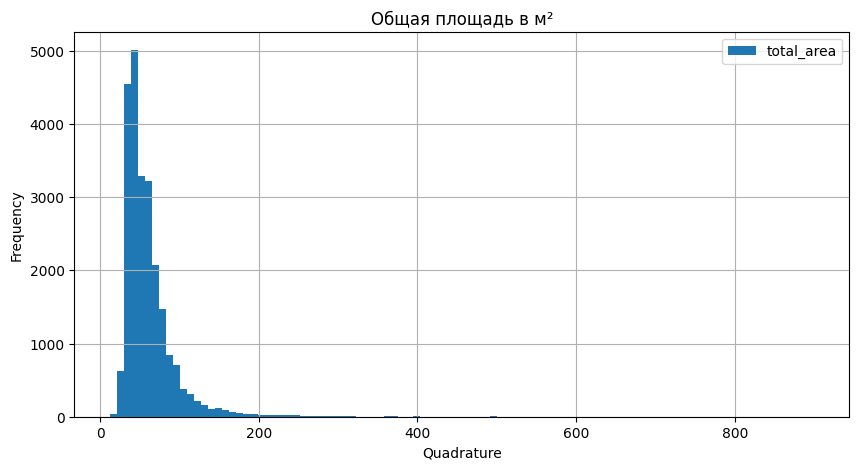

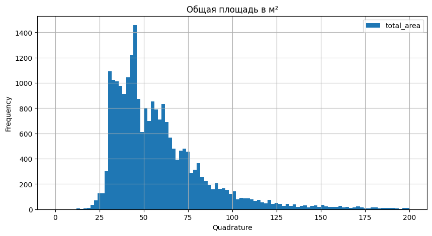

```
count    23613.000000
mean        60.340678
std         35.648988
min         12.000000
25%         40.000000
50%         52.000000
75%         69.800000
max        900.000000
Name: total_area, dtype: float64
```

```python
# Общая площадь
data.plot(y='total_area', kind='hist', bins=100, figsize=(10, 5), grid=True, title='Общая площадь в м²')
# Задание названия оси абсцисс
plt.xlabel('Quadrature')
# Показать график
plt.show()

data.plot(y='total_area', kind='hist', bins=100, range=(0, 200), figsize=(10, 5),
          grid=True, title='Общая площадь в м²')
# Задание названия оси абсцисс
plt.xlabel('Quadrature')
# Показать график
plt.show()

data['total_area'].describe()
```

```
Количество равно - 99
```

```
count    23515.0
mean        59.0
std         29.0
min         12.0
25%         40.0
50%         52.0
75%         69.0
max        257.0
Name: total_area, dtype: float64
```

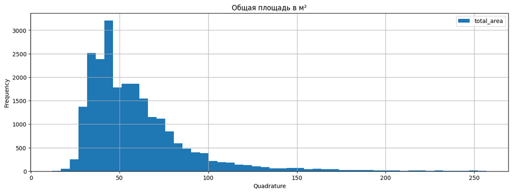

```python
# Подсчет количества квартир с общей площадью 257 м²
count_total_area = data.query('total_area >= 257').shape[0]
print(f'Количество равно - {count_total_area}')


# Построим график, исключив из анализа строки, где общая площадь составляет 257 м² или больше.
data.query('total_area <= 257', inplace=True)

# Проверим замену
display(data['total_area'].describe().round())

data.plot(y='total_area', kind='hist', bins=50, figsize=(15, 5),
          grid=True, title='Общая площадь в м²')

# Задание названия оси абсцисс
plt.xlabel('Quadrature')

# Показать график
plt.show()
```

По полученным графикам можно сделать вывод, что самый большой показатель площади квартир находится в пределах от ~30 м² (скорее всего это студии) до ~45 м². Недвижимость с показателем значения больше 125 м² не такая популярная на площадке и идет на убывание.

**Жилая площадь**

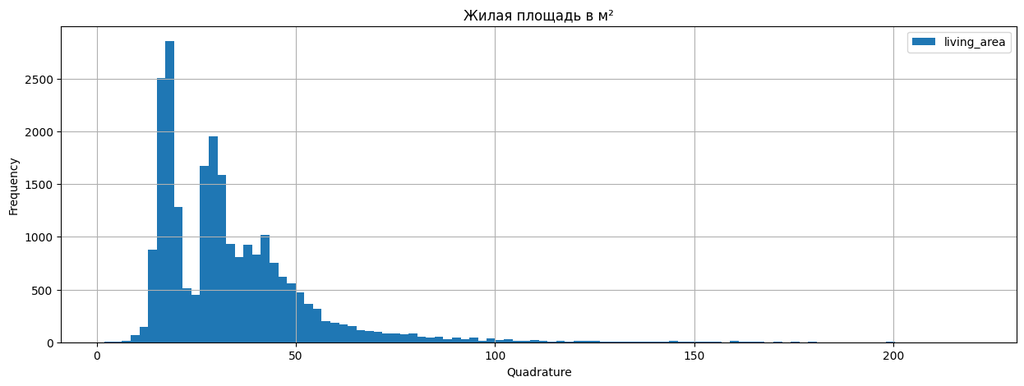

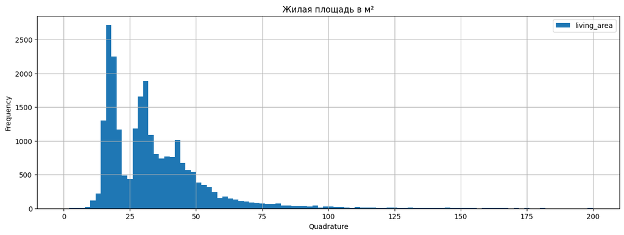

```
count    23515.000000
mean        33.554271
std         18.936105
min          2.000000
25%         18.800000
50%         30.000000
75%         42.000000
max        220.000000
Name: living_area, dtype: float64
```

```python
# Жилая площадь
data.plot(y='living_area', kind='hist', bins=100, figsize=(15, 5), grid=True, title='Жилая площадь в м²')
# Задание названия оси абсцисс
plt.xlabel('Quadrature')
# Показать график
plt.show()

data.plot(y='living_area', kind='hist', bins=100, range=(0, 200), figsize=(15, 5),
          grid=True, title='Жилая площадь в м²')
# Задание названия оси абсцисс
plt.xlabel('Quadrature')
# Показать график
plt.show()

data['living_area'].describe()
```

```
Количество равно - 96
```

```
count    23420.0
mean        33.0
std         17.0
min          2.0
25%         19.0
50%         30.0
75%         42.0
max        132.0
Name: living_area, dtype: float64
```

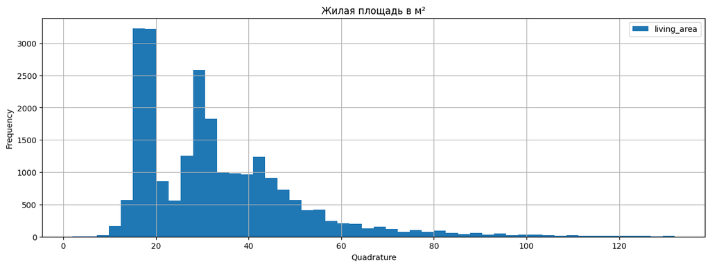

```python
# Подсчет количества квартир с жилой площадью 132 м²

count_living_area = data.query('living_area >= 132').shape[0]
print(f'Количество равно - {count_living_area}')


# Построим график, исключив из анализа строки, где жилая площадь составляет 140 м² или больше.
data.query('living_area <= 132', inplace=True)

# Проверим замену
display(data['living_area'].describe().round())

data.plot(y='living_area', kind='hist', bins=50, figsize=(15, 5),
          grid=True, title='Жилая площадь в м²')

# Задание названия оси абсцисс
plt.xlabel('Quadrature')

# Показать график
plt.show()
```

**Площадь кухни**

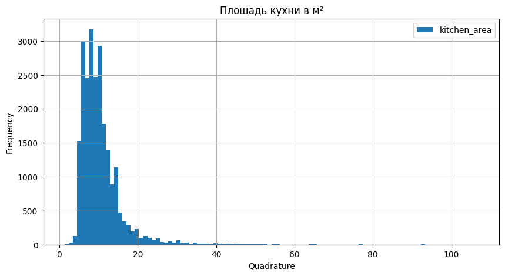

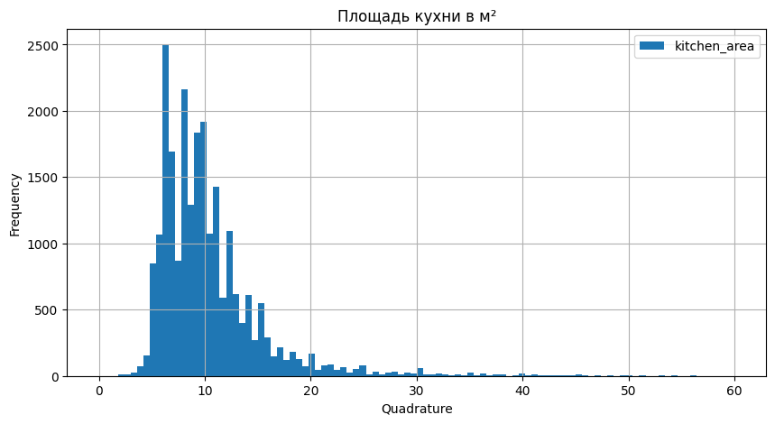

```
count    23420.000000
mean        10.383626
std          5.501995
min          1.300000
25%          7.000000
50%          9.000000
75%         12.000000
max        107.000000
Name: kitchen_area, dtype: float64
```

```python
# Площадь кухни

data.plot(y='kitchen_area', kind='hist', bins=100, figsize=(10, 5), grid=True, title='Площадь кухни в м²')

# Задание названия оси абсцисс
plt.xlabel('Quadrature')

# Показать график
plt.show()

data.plot(y='kitchen_area', kind='hist', bins=100, range=(0, 60), figsize=(10, 5),
          grid=True, title='Площадь кухни в м²')

# Задание названия оси абсцисс
plt.xlabel('Quadrature')

# Показать график
plt.show()

data['kitchen_area'].describe()
```

```
Количество равно - 91
```

```
count    23331.0
mean        10.0
std          5.0
min          1.0
25%          7.0
50%          9.0
75%         12.0
max         42.0
Name: kitchen_area, dtype: float64
```

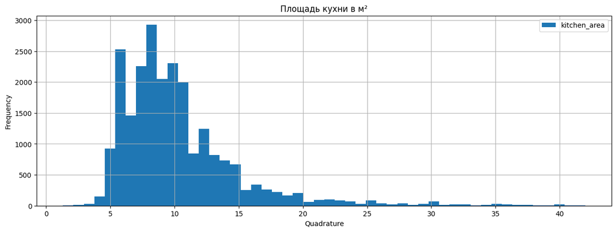

```python
# Подсчет количества квартир с площадью кухни от 42 м²
count_kitchen_area = data.query('kitchen_area >= 42').shape[0]
print(f'Количество равно - {count_kitchen_area}')


# Построим график, исключив из анализа строки, где площадь кухни составляет 42 м² или больше.
data.query('kitchen_area <= 42', inplace=True)

# Проверим замену
display(data['kitchen_area'].describe().round())

data.plot(y='kitchen_area', kind='hist', bins=50, figsize=(15, 5),
          grid=True, title='Площадь кухни в м²')
# Задание названия оси абсцисс
plt.xlabel('Quadrature')
# Показать график
plt.show()
```

По показателям площади кухни можно сделать вывод, что самая популярная квадратура для кухни это от 6 до 11 м².

**Цена объекта**

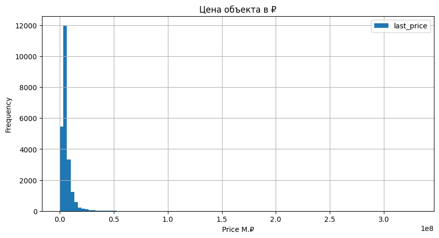

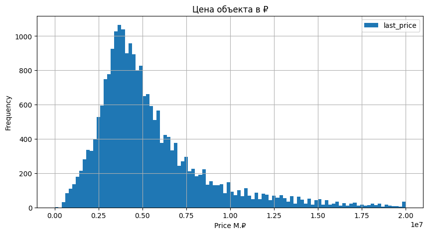

```
count        23331.0
mean       5986743.0
std        6182101.0
min          12190.0
25%        3400000.0
50%        4600000.0
75%        6650000.0
max      330000000.0
Name: last_price, dtype: float64
```

```python
# Цена объекта
data.plot(y='last_price', kind='hist', bins=100, figsize=(10, 5), grid=True, title='Цена объекта в ₽')
# Задание названия оси абсцисс
plt.xlabel('Price M.₽')
# Показать график
plt.show()

data.plot(y='last_price', kind='hist', bins=100, range=(0, 20000000), figsize=(10, 5),
          grid=True, title='Цена объекта в ₽')
# Задание названия оси абсцисс
plt.xlabel('Price M.₽')
# Показать график
plt.show()

data['last_price'].describe().round()
```

```python
pd.qcut(data['last_price'], q=12)
```

[output not shown]

[output cut: 23318 more lines]

```
Количество равно - 100
```

```
count     0.023233
mean      5.747636
std       4.203447
min       0.012190
25%       3.400000
50%       4.600000
75%       6.600000
max      38.000000
Name: last_price, dtype: float64
```

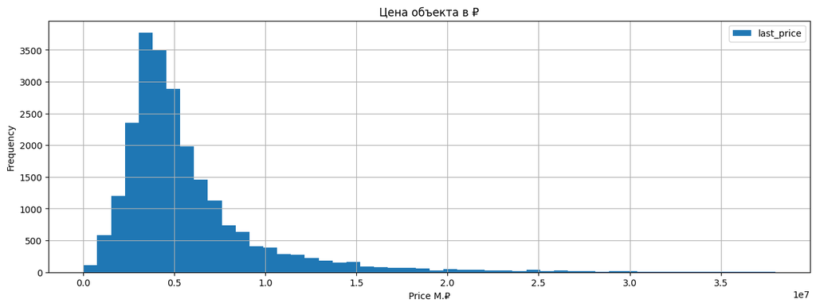

```python
# Подсчет количества квартир с ценой от 38000000
count_last_price = data.query('last_price >= 38000000').shape[0]
print(f'Количество равно - {count_last_price}')

# Построим график, исключив из анализа строки, в которых цена квартиры равна или превышает 38000000 рублей.
data.query('last_price <= 38000000', inplace=True)
# Проверим замену
display(data['last_price'].describe() / 1000000)
data.plot(y='last_price', kind='hist', bins=50, figsize=(15, 5),
          grid=True, title='Цена объекта в ₽')
# Задание названия оси абсцисс
plt.xlabel('Price M.₽')
# Показать график
plt.show()
```

**Количество комнат**

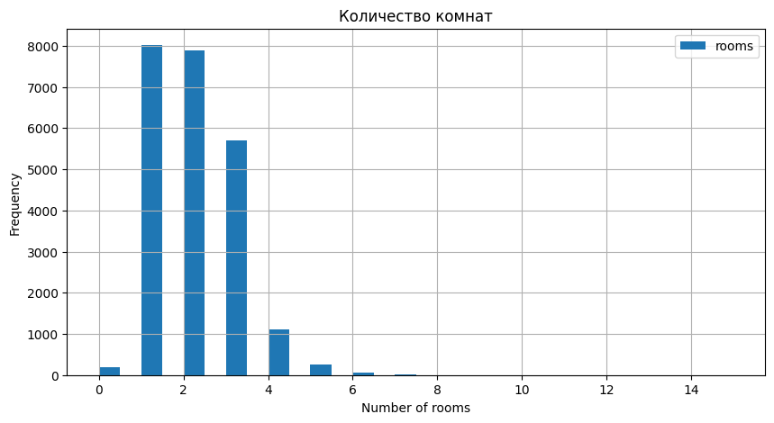

```python
# Количество комнат
data.plot(y='rooms', kind='hist', bins=30, range=(0, 15), figsize=(10, 5), grid=True, title='Количество комнат')
# Задание названия оси абсцисс
plt.xlabel('Number of rooms')
# Показать график
plt.show()
```

```
Количество равно - 25
```

```
count    23230.000000
mean         2.027249
std          0.986450
min          0.000000
25%          1.000000
50%          2.000000
75%          3.000000
max          7.000000
Name: rooms, dtype: float64
```

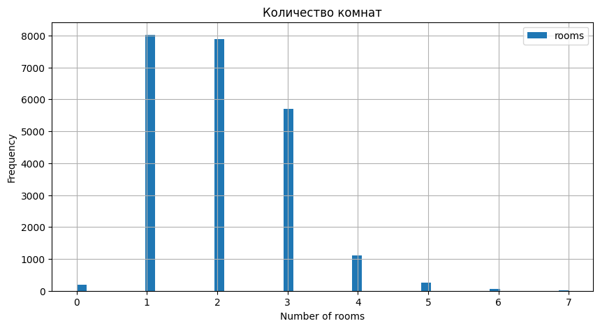

```python
# Подсчет количества квартир с количеством комнат от 7, это делается исходя из графика выше

count_rooms = data.query('rooms >= 7').shape[0]
print(f'Количество равно - {count_rooms}')
# Построим график, исключив из анализа строки, где количество комнат составляет 7 или меньше.
data.query('rooms <= 7', inplace=True)
# Проверим замену
display(data['rooms'].describe())

data.plot(y='rooms', kind='hist', bins=50, range=(0, 7), figsize=(10, 5),
          grid=True, title='Количество комнат')
# Задание названия оси абсцисс
plt.xlabel('Number of rooms')

# Показать график
plt.show()
```

На гистограмме видно, что наибольшее количество объявлений приходится на квартиры с 1 или 2 комнатами. Как и ожидалось, наименее распространены объявления о квартирах с 7 и более комнатами. Квартиры студии тоже не популярны. Распределение данных близко к нормальному.

**Высота потолков**

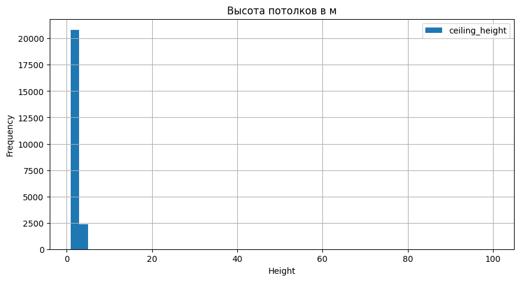

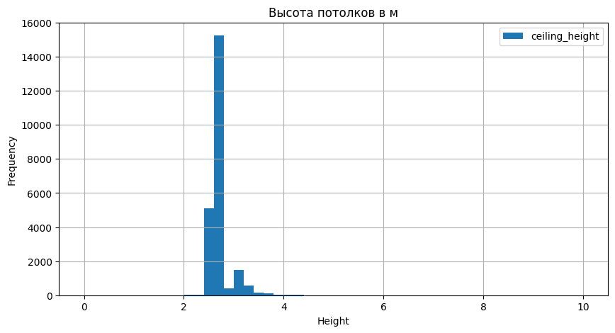

```
count    23230.000000
mean         2.718414
std          0.994902
min          1.000000
25%          2.600000
50%          2.650000
75%          2.700000
max        100.000000
Name: ceiling_height, dtype: float64
```

```python
# Высота потолков
data.plot(y='ceiling_height', kind='hist', bins=50, figsize=(10, 5), grid=True, title='Высота потолков в м')
# Задание названия оси абсцисс
plt.xlabel('Height')
# Показать график
plt.show()

data.plot(y='ceiling_height', kind='hist', bins=50, range=(0, 10), figsize=(10, 5),
          grid=True, title='Высота потолков в м')
# Задание названия оси абсцисс
plt.xlabel('Height')
# Показать график
plt.show()

data['ceiling_height'].describe()
```

```
Количество равно - 33
```

```
count    23125.000000
mean         2.691109
std          0.203862
min          2.500000
25%          2.600000
50%          2.650000
75%          2.700000
max          5.000000
Name: ceiling_height, dtype: float64
```

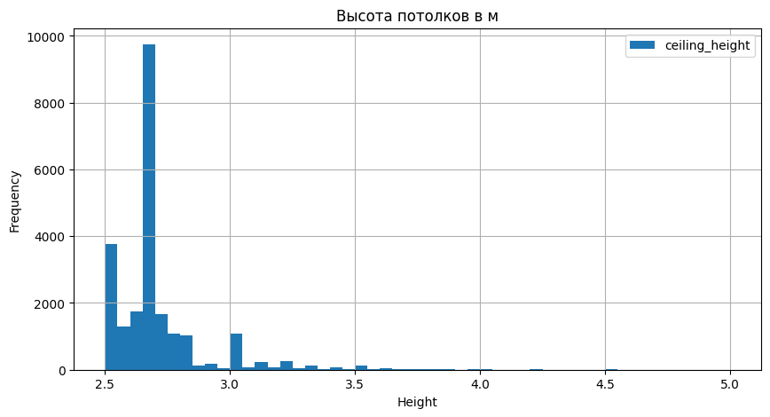

```python
# Подсчет количества квартир с высотой потолков от 5 метров, это делается исходя из графика выше
count_ceiling_high = data.query('ceiling_height >= 5').shape[0]
print(f'Количество равно - {count_ceiling_high}')

# Построим график, исключив из анализа строки, где высота потолков превышает 5 метров или менее 2,5 метров.
data.query('ceiling_height >= 2.5 and ceiling_height <= 5', inplace=True)
# Проверим замену
display(data['ceiling_height'].describe())

data.plot(y='ceiling_height', kind='hist', bins=50, figsize=(10, 5),
          grid=True, title='Высота потолков в м')
# Задание названия оси абсцисс
plt.xlabel('Height')
# Показать график
plt.show()
```

Больше всего квартир с высотой потолков от ~2,5 до ~3 метров. Медианное значение высоты потолков после коррекции составило 2,65 метра.

**Тип этажа квартиры («первый», «последний», «другой»)**

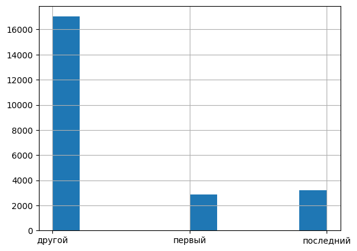

```python
# Тип этажа квартиры

data['floor_category'].hist()
```

Из графика видно, что люди неохотно покупают недвижимость на первых и последних этажах.

**Общее количество этажей в доме**

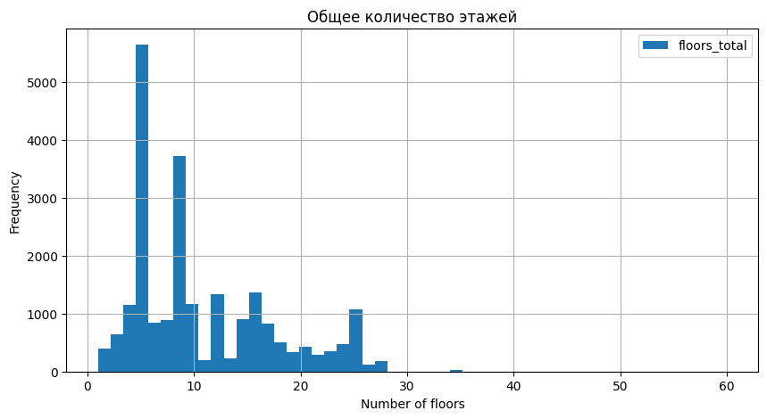

```
count    23125.000000
mean        10.740757
std          6.616084
min          1.000000
25%          5.000000
50%          9.000000
75%         16.000000
max         60.000000
Name: floors_total, dtype: float64
```

```python
# Общее количество этажей в доме
data.plot(y='floors_total', kind='hist', bins=50, figsize=(10, 5), grid=True, title='Общее количество этажей')
# Задание названия оси абсцисс
plt.xlabel('Number of floors')
# Показать график
plt.show()

data['floors_total'].describe()
```